# Homework 07 Solutions

Your Friendly Course Staff

Due Wednesday, October 26, 2016 (12pm ET) on Blackboard

# Homework 07: Shark Attacks!

# Instructions: Lab Exam / Homework 07

- For all lab exam questions, be sure to answer the question(s) asked.
- In addition to answering the questions, **write 1-3 sentences describing why you made certain choices in your graphic.** For example, why did you choose a histogram vs. density plot? Pie chart vs. rose diagram vs. bar chart vs. spine chart? Stacked vs. side-by-side bar chart? Why did you choose the bin width / number of bins in your histogram? Why did you choose the bandwidth and kernel that you picked in your density plot? Why did you decide to arrange the graphs the way you did (e.g. in a grid, horizontally, vertically). Etc.
- Remember, whenever you can supplement your answer with information from a statistical test, this is very beneficial! Feel free to run statistical tests and include this information as part of your answer.

### For all problems below, you should justify your answer with a single graph.

Using `facet_wrap()` or `facet_grid()` counts as one graph, while using `grid.arrange()` does not.

# Data: Shark Attacks!

Load the shark attack data from the course GitHub page at the following link: [https://raw.githubusercontent.com/sventura/315-code-and-datasets/master/data/attacks_test.csv]

The data is taken from Kaggle and was originally compiled by the global shark attack file. [More information is available here.](https://www.kaggle.com/teajay/global-shark-attacks)

### Reminder: The data differs slightly from what you saw in the pre-test!

### Be sure to update the link from which you download the data in your code!

[figure not shown]

# Problem 0

**Style Guide and Table of Contents**

1. Be consistent with the style guide that you select.

Also, watch out for having too many characters in a single line. (You can always separate a single long line in to multiple lines.)

2. Remember to include a floating table of contents in your submission.
3. Use your theme for all problems.

# Problem 1

**Victim Blaming?**

Graph: (10 points)

1. (4 points) Characterize the distribution of the `Type` of shark attack. Describe any interesting features you see.

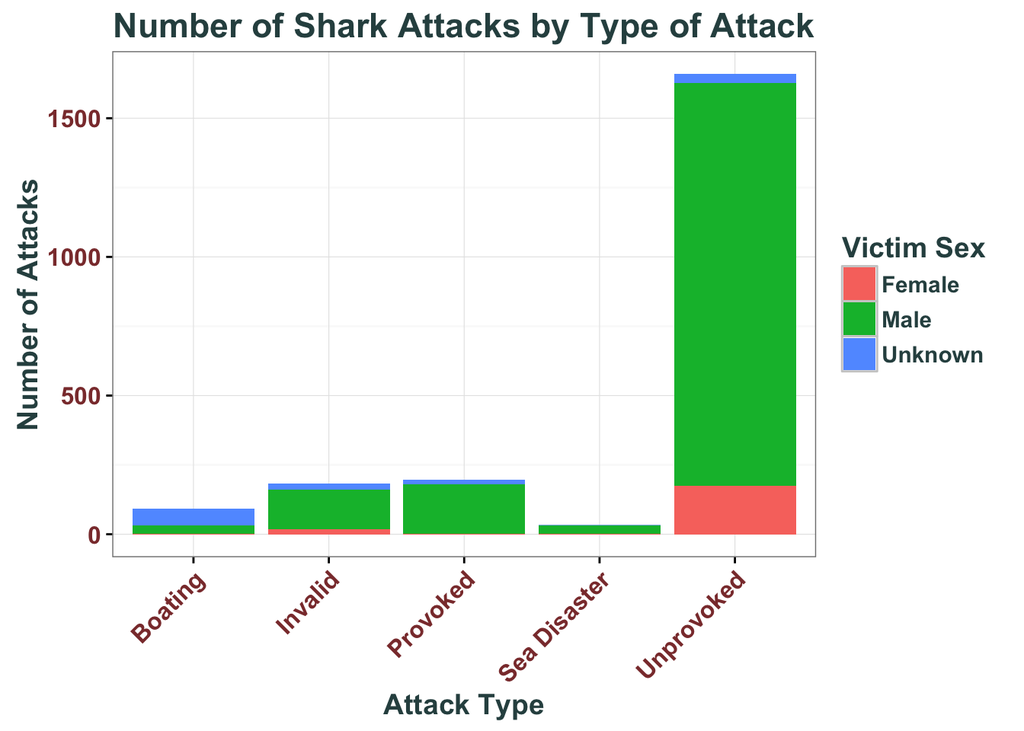

```r
shark_attacks <- mutate(shark_attacks, Type2 = ifelse(Type == "Boat","Boating",Type))
ggplot(data = shark_attacks, aes(x = Type2, fill = Sex)) + geom_bar() +
    ggtitle("Number of Shark Attacks by Type of Attack")  +
    xlab("Attack Type") + ylab("Number of Attacks") +
    scale_fill_discrete(name = "Victim Sex",
                        labels=c("Female", "Male", "Unknown")) +
    my_theme +
    theme(axis.text.x = element_text(angle = 45, hjust = 1))
```

From the figure we can see that the vast majority of the attacks are “Unprovoked”. The “Invalid” and “Provoked” types are the next most frequent categories but there are about 1/8 as many of each as there are “Unprovoked” attacks. The types “Boat” and “Boating” are combined into a single category which occurs about half as frequently as “Invalid” and “Provoked” attacks. The final type of attack “Sea Disaster” is a very uncommon occurrence.

2. (3 points) Compare the different conditional distributions of `Sex` given each `Type` of shark attack. Are female victims relatively more or less common in any of the shark attack types? Are unknown-gender victims more or less common in any of the shark attack types?

A noticeable number of female victims show up only in the “Invalid” and “Unprovoked” types of attacks although this may be partially because they are two of the larger categories. It is certainly the case that there are relatively more female victims in the “Invalid” category than in the “Provoked” category but comparisons between categories is more difficult. Victims of unknown `Sex` also appear to be more common in “Boating” attacks and possibly in “Invalid” attacks.

3. (5 points) Write 1-3 sentences describing why you made certain choices in your graphic.

Using a stacked bar chart in a figure shows both the marginal distribution of `Type` and the conditional distribution of `Sex` (conditioned on `Type`). The types “Boat” and “Boating” are combined since the last year in which a “Boating” attack was recorded is 1955 and the first year a “Boat” attack was recorded is 1958. The fact that there is no overlap in the years these were recorded suggest that the difference may only be one of reporting.

# Problem 2

**Attacking All Ages**

Graph: (10 points)

1. (8 points) Characterize the distribution of the `Age` of shark attack victims. Describe any interesting features you see.

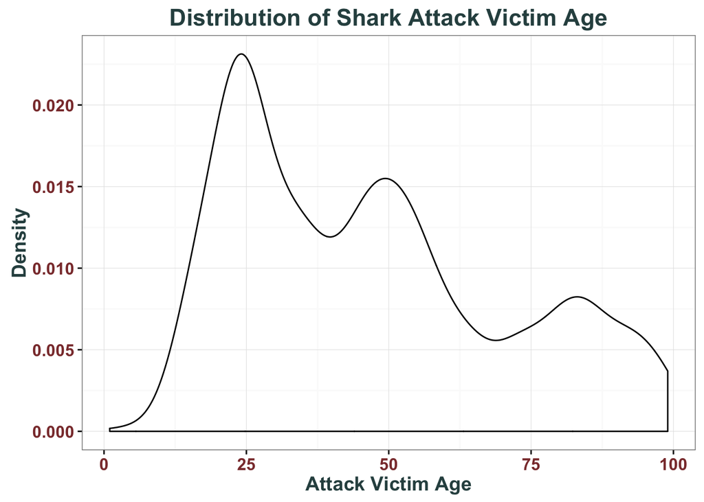

```r
ggplot(data = filter(shark_attacks, Age != -5), aes(x = Age)) + geom_density(bw = 4) +
    ggtitle("Distribution of Shark Attack Victim Age")  +
    xlab("Attack Victim Age") + ylab("Density") +
    my_theme
```

There are 681 observations marked with an Age of -5 of 2165 observations or 31% of the total. There correspond to missing/unknowna ges, and thus are excluded from the graphic as they do not give us information about the distribution the age of shark attack victims.

Looking at the remaining observations there appear to be three modes, at 25, 50 and 80. With the one at 25 being the largest, followed by the mode at 50 and then the mode at 80. The oldest recorded victim was 99 years old, and the youngest was 1. The distribution is somewhat skewed and declines as `Age` increases but the tail is fairly heavy.

2. (2 points) Is the distribution of `Age` normally distributed? Why or why not?

The distribution of `Age` is not normally distributed. If we ignore the missing values, the distribution is not symmetric and appears to have three modes as shown in the figure. Even if we knew what the missing values were and including them made the distribution symmetric and unimodal it would still not contain values less than zero and so would not be normally distributed.

3. (5 points) Write 1-3 sentences describing why you made certain choices in your graphic.

A natural choice for examining the distribution of a continuous variable like Age is a density plot. The missing values were excluded because the value of -5 was assigned arbitrarily and thus does not give useful information about the distribution of the age of shark attack victims. The bandwidth of 4 was selected to create a generally smooth density that still displayed prominent modes.

### Sam Says

It’s perfectly fine to use a density plot here, even though the ages are measured in integer values. That said, you should use a bandwidth that spans at least one year, so that we don’t see tiny bumps in the distribution corresponding to each unique value of age. We used a bandwidth of 4 to smooth out the bumps corresponding to the integer values of age.

# Problem 3

**Gender Bias?**

Graph: (10 points)

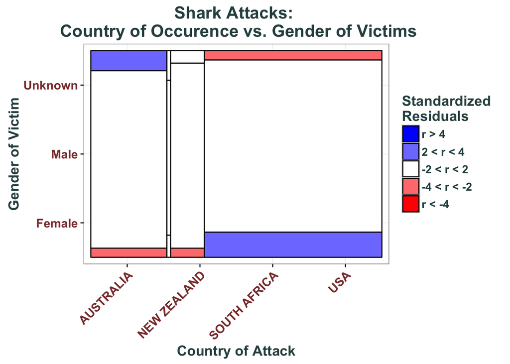

```r
shark_attacks <- mutate(shark_attacks, Sex = factor(Sex, labels = c("Female", "Male", "Unknown")))
ggplot(data = shark_attacks) +
  geom_mosaic(aes(x = Country, y = Sex)) +
  mosaic_legend() +
  ggtitle("Shark Attacks: \n Country of Occurence vs. Gender of Victims") +
  labs(x = "Country of Attack", y = "Gender of Victim") +
  my_theme +
  theme(axis.text.x = element_text(angle = 45, hjust = 1))
```

1. (8 points)

2. (2 points)

3. (5 points)

I chose to use a mosaic plot because it displays the conditional distribution for the gender of shark attack victims based on the country of the shark attack, which allows us to see if there is a difference between them. It also shows the residuals for a Pearson chi-squared test, which allows us to quickly confirm whether there is a relationship between the two variables based on whether there are any residuals that are significantly larger or smaller than expected.

*Note: A bar graph with a supporting chi-squared test would also be appropriate here.*

# Problem 7

**Days Are Numbered** Graph: (10 points)

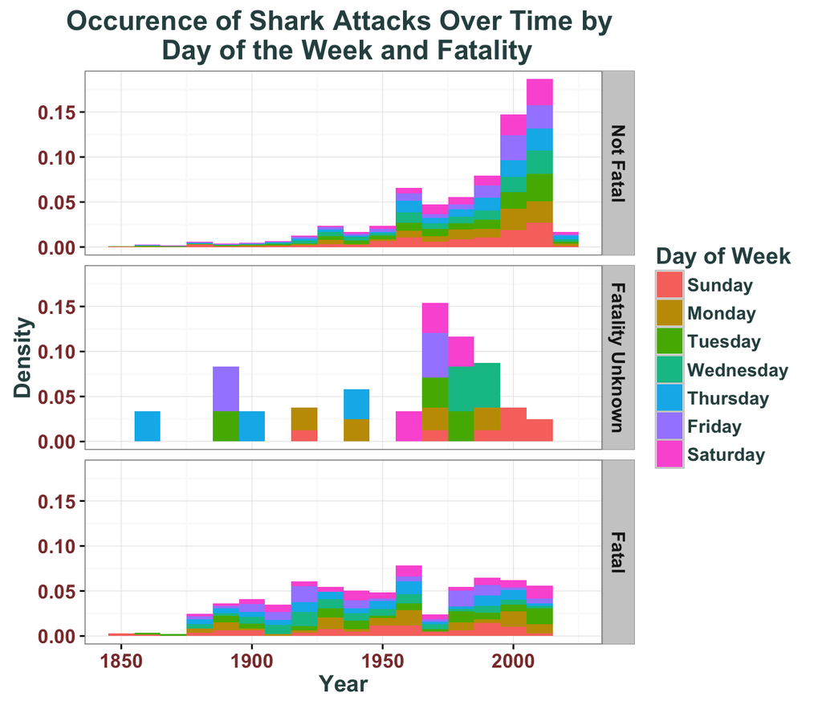

```r
sharks_subset1 <- mutate(shark_attacks,
                    day_of_week = weekdays(as.Date(Date)),
                    day_of_week = factor(day_of_week, levels = c("Sunday", "Monday", "Tuesday", "Wednesday", "Thursday", "Friday", "Saturday")))

shark_attacks$Fatal <- as.factor(shark_attacks$Fatal)
fatal_labels <- c("Y" = "Fatal", "N" = "Not Fatal", "UNKNOWN" = "Fatality Unknown")


sharks_subset1$Date <- as.Date(sharks_subset1$Date)
sharks_subset1$Year <- as.numeric(format(sharks_subset1$Date, "%Y"))

ggplot(sharks_subset1[which(sharks_subset1$Year >= 1850),]) +
  geom_histogram(aes(y = ..density.., x = Year, fill = day_of_week), binwidth = 10) +
  facet_grid(Fatal~., labeller = as_labeller(fatal_labels)) +
  labs(x = "Year", y = "Density") +
  scale_fill_discrete(name = "Day of Week") +
  ggtitle("Occurence of Shark Attacks Over Time by \n Day of the Week and Fatality") +
  my_theme
```

```r
table(sharks_subset1$day_of_week)
```

```
##
##    Sunday    Monday   Tuesday Wednesday  Thursday    Friday  Saturday
##       455       265       280       255       262       248       400
```

```r
chisq.test(sharks_subset1$day_of_week, sharks_subset1$Fatal)
```

```
##
##  Pearson's Chi-squared test
##
## data:  sharks_subset1$day_of_week and sharks_subset1$Fatal
## X-squared = 7.5401, df = 12, p-value = 0.82
```

We see that 1955-1965s and 2005-2010s had the most fatal shark attacks occurring on Saturdays. The 1945s-1965s and 1985-1995s had the most fatal shark attacks on Sundays.

Through facetting, we see the conditional distributions of year given day of the week for each category of `Fatal`. And the fill of the histogram visualizes the conditional distribution of year given day of the week and is displayed for each category of `Fatal`.

I chose to treat year as a continuous variable, and thus I used a density histogram displaying the stacked conditional distributions. I facetted by fatality because it allows us to compare the distributions of years given day of the week for each of the three categories of fatality - fatal attack, non-fatal attack and unknown. Overall, this graphical arrangement allows us to most effectively answer the questions at hand regarding the different relationships between one continuous and two categorical variables.

# Problem 8

(BONUS: 2 points)

Before Monday’s lecture, read the “Lecture 15 R Demo” file on Blackboard, and run all of the code – including the 3-D scatterplot code.

You don’t have to turn anything in for this problem. **Everyone will receive bonus credit for this problem if class participation on Monday as at a satisfactory level.** This means:

- Asking and answering questions
- Not being disruptive in class
- Not starting to gather your things / zip up your bags while there is still time left and the instructor is still speaking / writing / lecturing